# 1.Nhập dữ liệu và thống kê những thông tin cơ bản

## Cách thực hiện

Tạo mới một tập tin notebook và import vào các thư viện thao tác với tập dữ liệu và số: Numpy, Pandas, thư viện vẽ đồ thị, trực quan hóa dữ liệu: seaborn, matplotlib. Sau đó đọc dữ liệu đầu vào.

```python
# linear algebra
import numpy as np
# data processing
import pandas as pd
#data visualization
import seaborn as sns
%matplotlib inline
from matplotlib import pyplot as plt
from matplotlib import style
with open('F:\\DOWNLOAD\\x08ankadd.csv') as f:
          df = pd.read_csv(f, dtype={'age': np.int64, 'duration': np.int64, 'cons.price.idx': np.float64})
```

Xem xét dữ liệu ban đầu với hàm head() và info()

```python
df.head(12)
```

|  | age | job | marital | education | default | housing | loan | contact | month | day_of_week | ... | campaign | pdays | previous | poutcome | emp.var.rate | cons.price.idx | cons.conf.idx | euribor3m | nr.employed | y |
| --- | --- | --- | --- | --- | --- | --- | --- | --- | --- | --- | --- | --- | --- | --- | --- | --- | --- | --- | --- | --- | --- |
| 0 | 30 | blue-collar | married | basic.9y | 0 | 1 | 0 | cellular | may | fri | ... | 2 | 999 | 0 | nonexistent | -1.8 | 92.893 | -46.2 | 1.313 | 5099.1 | no |
| 1 | 39 | services | single | high.school | 0 | 0 | 0 | telephone | may | fri | ... | 4 | 999 | 0 | nonexistent | 1.1 | 93.994 | -36.4 | 4.855 | 5191.0 | no |
| 2 | 25 | services | married | high.school | 0 | 1 | 0 | telephone | jun | wed | ... | 1 | 999 | 0 | nonexistent | 1.4 | 94.465 | -41.8 | 4.962 | 5228.1 | no |
| 3 | 38 | services | married | basic.9y | 0 | 2 | 2 | telephone | jun | fri | ... | 3 | 999 | 0 | nonexistent | 1.4 | 94.465 | -41.8 | 4.959 | 5228.1 | no |
| 4 | 47 | admin. | married | university.degree | 0 | 1 | 0 | cellular | nov | mon | ... | 1 | 999 | 0 | nonexistent | -0.1 | 93.200 | -42.0 | 4.191 | 5195.8 | no |
| 5 | 32 | services | single | university.degree | 0 | 0 | 0 | cellular | sep | thu | ... | 3 | 999 | 2 | failure | -1.1 | 94.199 | -37.5 | 0.884 | 4963.6 | no |
| 6 | 32 | admin. | single | university.degree | 0 | 1 | 0 | cellular | sep | mon | ... | 4 | 999 | 0 | nonexistent | -1.1 | 94.199 | -37.5 | 0.879 | 4963.6 | no |
| 7 | 41 | entrepreneur | married | university.degree | 2 | 1 | 0 | cellular | nov | mon | ... | 2 | 999 | 0 | nonexistent | -0.1 | 93.200 | -42.0 | 4.191 | 5195.8 | no |
| 8 | 31 | services | divorced | professional.course | 0 | 0 | 0 | cellular | nov | tue | ... | 1 | 999 | 1 | failure | -0.1 | 93.200 | -42.0 | 4.153 | 5195.8 | no |
| 9 | 35 | blue-collar | married | basic.9y | 2 | 0 | 0 | telephone | may | thu | ... | 1 | 999 | 0 | nonexistent | 1.1 | 93.994 | -36.4 | 4.855 | 5191.0 | no |
| 10 | 25 | services | single | basic.6y | 2 | 1 | 0 | cellular | jul | thu | ... | 1 | 999 | 0 | nonexistent | 1.4 | 93.918 | -42.7 | 4.958 | 5228.1 | no |
| 11 | 36 | self-employed | single | basic.4y | 0 | 0 | 0 | cellular | jul | thu | ... | 1 | 999 | 0 | nonexistent | 1.4 | 93.918 | -42.7 | 4.968 | 5228.1 | no |

12 rows × 21 columns

```python
df.info()
```

```
<class 'pandas.core.frame.DataFrame'>
RangeIndex: 4119 entries, 0 to 4118
Data columns (total 21 columns):
 #   Column          Non-Null Count  Dtype
---  ------          --------------  -----
 0   age             4119 non-null   int64
 1   job             4119 non-null   object
 2   marital         4119 non-null   object
 3   education       4119 non-null   object
 4   default         4119 non-null   int64
 5   housing         4119 non-null   int64
 6   loan            4119 non-null   int64
 7   contact         4119 non-null   object
 8   month           4119 non-null   object
 9   day_of_week     4119 non-null   object
 10  duration        4119 non-null   int64
 11  campaign        4119 non-null   int64
 12  pdays           4119 non-null   int64
 13  previous        4119 non-null   int64
 14  poutcome        4119 non-null   object
 15  emp.var.rate    4119 non-null   float64
 16  cons.price.idx  4119 non-null   float64
 17  cons.conf.idx   4119 non-null   float64
 18  euribor3m       4119 non-null   float64
 19  nr.employed     4119 non-null   float64
 20  y               4119 non-null   object
dtypes: float64(5), int64(8), object(8)
memory usage: 675.9+ KB
```

Thống kê chỉ số của các thuộc tính định lượng như: đến số giá trị, giá trị lớn nhất, nhỏ nhất, trung bình, độ lệch chuẩn, tứ phân vị,...

```python
df.describe()
```

|  | age | default | housing | loan | duration | campaign | pdays | previous | emp.var.rate | cons.price.idx | cons.conf.idx | euribor3m | nr.employed |
| --- | --- | --- | --- | --- | --- | --- | --- | --- | --- | --- | --- | --- | --- |
| count | 4119.000000 | 4119.000000 | 4119.000000 | 4119.000000 | 4119.000000 | 4119.000000 | 4119.000000 | 4119.000000 | 4119.000000 | 4119.000000 | 4119.000000 | 4119.000000 | 4119.000000 |
| mean | 40.113620 | 0.390143 | 0.579024 | 0.212430 | 256.788055 | 2.537266 | 960.422190 | 0.190337 | 0.084972 | 93.579704 | -40.499102 | 3.621356 | 5166.481695 |
| std | 10.313362 | 0.792455 | 0.542964 | 0.467269 | 254.703736 | 2.568159 | 191.922786 | 0.541788 | 1.563114 | 0.579349 | 4.594578 | 1.733591 | 73.667904 |
| min | 18.000000 | 0.000000 | 0.000000 | 0.000000 | 0.000000 | 1.000000 | 0.000000 | 0.000000 | -3.400000 | 92.201000 | -50.800000 | 0.635000 | 4963.600000 |
| 25% | 32.000000 | 0.000000 | 0.000000 | 0.000000 | 103.000000 | 1.000000 | 999.000000 | 0.000000 | -1.800000 | 93.075000 | -42.700000 | 1.334000 | 5099.100000 |
| 50% | 38.000000 | 0.000000 | 1.000000 | 0.000000 | 181.000000 | 2.000000 | 999.000000 | 0.000000 | 1.100000 | 93.749000 | -41.800000 | 4.857000 | 5191.000000 |
| 75% | 47.000000 | 0.000000 | 1.000000 | 0.000000 | 317.000000 | 3.000000 | 999.000000 | 0.000000 | 1.400000 | 93.994000 | -36.400000 | 4.961000 | 5228.100000 |
| max | 88.000000 | 2.000000 | 2.000000 | 2.000000 | 3643.000000 | 35.000000 | 999.000000 | 6.000000 | 1.400000 | 94.767000 | -26.900000 | 5.045000 | 5228.100000 |

# 2.Lấy ra 5 thuộc tính có số lượng giá trị rỗng nhiều nhất

```python
total = df.isnull().sum().sort_values(ascending=False)
percent_1 = df.isnull().sum()/df.isnull().count()*100
percent_2 = (round(percent_1,1)).sort_values(ascending=False)
missing_data = pd.concat([total,percent_2], axis=1, keys=['Total', '%'])
missing_data.head(5)
```

|  | Total | % |
| --- | --- | --- |
| y | 0 | 0.0 |
| day_of_week | 0 | 0.0 |
| job | 0 | 0.0 |
| marital | 0 | 0.0 |
| education | 0 | 0.0 |

Có thể thấy bảng dữ liệu này không bị thiếu dữ liệu

# 3. Xem xét thống kê giữa thuộc tính độ tuổi (age), tình trạng hôn nhân (marital) có giá trị 'married' và 'single' với đã có khoản vay hay chưa

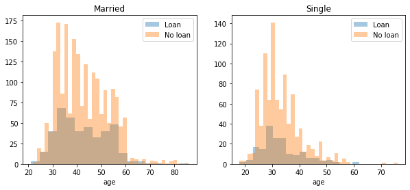

```python
loan = 'Loan'
no_loan = 'No loan'
fig, axes = plt.subplots(nrows=1, ncols=2,figsize=(10,4))
married = df[df['marital']=='married']
single = df[df['marital']=='single']
ax = sns.distplot(married[married['loan']==1].age.dropna(), bins=18, label = loan, ax = axes[0], kde =False)
ax = sns.distplot(married[married['loan']==0].age.dropna(), bins=40, label = no_loan, ax = axes[0], kde =False)
ax.legend()
ax.set_title('Married')
ax = sns.distplot(single[single['loan']==1].age.dropna(), bins=18, label = loan, ax = axes[1], kde =False)
ax = sns.distplot(single[single['loan']==0].age.dropna(), bins=40, label = no_loan, ax = axes[1], kde =False)
ax.legend()
_ = ax.set_title('Single')
```

[output not shown]

# 4. Xem xét thống kê giữa thuộc tính tín dụng mặc định (default) và tình trạng hôn nhân (marital) với có vay nợ hay chưa (loan), phân biệt theo người làm công việc nội trợ (housing)

```
C:\Users\NGOC HA\anaconda3\lib\site-packages\seaborn\axisgrid.py:733: UserWarning: Using the pointplot function without specifying `hue_order` is likely to produce an incorrect plot.
  warnings.warn(warning)
```

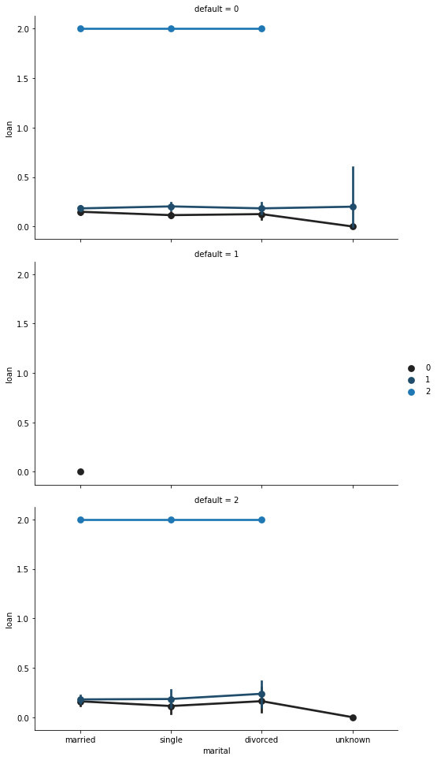

```python
FacetGrid = sns.FacetGrid(df, row='default', height=4.5, aspect=1.6)
FacetGrid.map(sns.pointplot, 'marital', 'loan', 'housing', pallet=None, order=None )
FacetGrid.add_legend()
```

Nhìn vào biểu đồ tình trạng hôn nhân, ta thấy:

```
* Những người không làm công việc nội trợ (0) có tỉ lệ đã vay nợ thấp hơn ở tất cả tình trạng hôn nhân. Trong đó, thấp nhất là những khách hàng độc thân. Người ly dị và đã kết hôn có tỉ lệ vay nợ ngang nhau, chênh lệch không đáng kể.
* Những người làm việc nội trợ có tỉ lệ vay nợ cao hơn ở tất cả tình trạng hôn nhâ. Trong đó, cao nhất là những khách hàng đã ly dị, kế theo là khách hàng độc thân. Tuy nhiên khaorng tỉ lệ chênh lệch giữa khách hàng đã kết hôn và độc thân là không đáng kể.
```

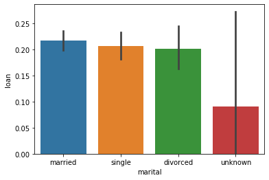

```python
sns.barplot(x='marital', y='loan', data=df)
```

Biểu đồ nay cho thấy rõ nhất tỉ lệ vay nợ của khách hàng đã kết hôn là cao nhất.

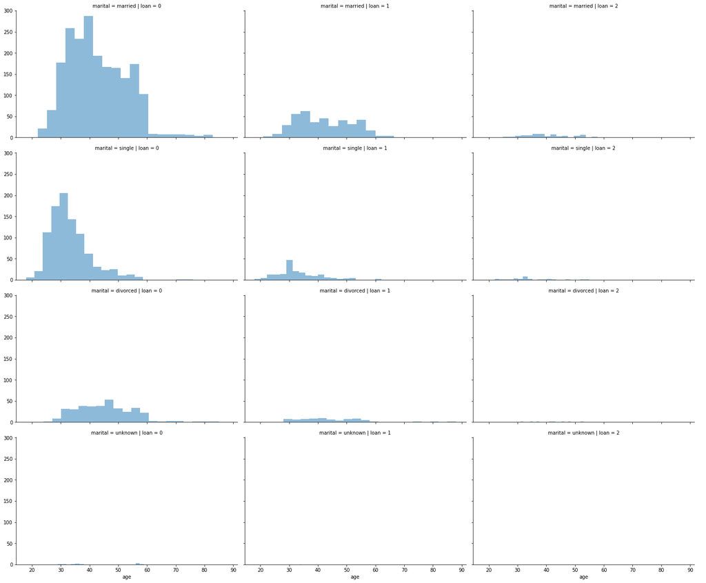

```python
grid = sns.FacetGrid(df, col='loan', row='marital', height=4.2, aspect=1.6)
grid.map(plt.hist, 'age', alpha=.5, bins=20)
grid.add_legend();
```

# 5. Thống kê việc làm đối với khả năng đã vay vốn hay chưa

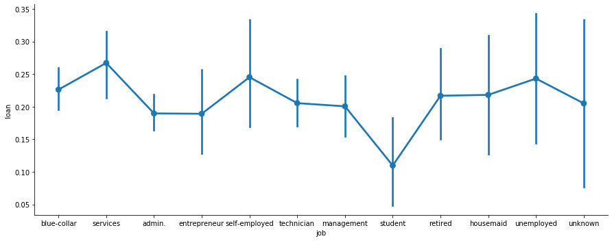

```python
axes = sns.catplot('job','loan',
                  data=df, aspect = 2.5, kind='point')
```

Sơ đồ trên là sơ đồ biểu diễn mối quan hệ giữa công việc và khả năng vay vốn của khách hàng.

Ở đây, ta cũng có thể thấy 3 ngành nghề có khả năng vay vốn cao nhất lần lượt là ngành dịch vụ, doanh nghiệp tự chủ và người thất nghiệp. Đây cũng phản ánh thực tế rõ nhất đối với mối quan hệ giữa ngành nghề, công việc và khả năng chi trả của khách hàng.

# 6. Tiền xử lý dữ liệu

Do bảng dữ liệu này đã đầy đủ các giá trị, ta không cần tiến ahfnh xem xét các thuộc tính thiếu sót của bảng.

Thay vào đó, ta sẽ xem xét thuộc tính nào có giá trị khai thác và không ảnh hưởng đến giá trị khi khai thác các dữ liệu để thực hiện việc loại bỏ.

```python
df['y'].describe()
```

```
count     4119
unique       2
top         no
freq      3668
Name: y, dtype: object
```

Thuộc tính này có 2 giá trị khác nhau là yes và no. Tuy nhiên, thuộc tính này không rõ ràng là chỉ cái gì. Do đó, chúng ta có thể loại bỏ những thuộc tính mà chúng ta không cần đến trong quá trình khai thác dữ liệu.

```python
df['pdays'].describe()
```

```
count    4119.000000
mean      960.422190
std       191.922786
min         0.000000
25%       999.000000
50%       999.000000
75%       999.000000
max       999.000000
Name: pdays, dtype: float64
```

Thuộc tính này có giá trị đồng nhất cả 4 thuật toán là 25%, 50%, 75% và max. Do đó, ta có thể thấy dữ liệu ở thuộc tính này bị lỗi. Dựa vào đó, ta có thể lựa chọn loại bỏ.

```python
df['previous'].describe()
```

```
count    4119.000000
mean        0.190337
std         0.541788
min         0.000000
25%         0.000000
50%         0.000000
75%         0.000000
max         6.000000
Name: previous, dtype: float64
```

Tương tự như thuộc tính pdays. Thuộc tính này có giá trị đồng nhất cả 4 thuật toán là 25%, 50%, 75% và min. Do đó, ta có thể thấy dữ liệu ở thuộc tính này bị lỗi. Dựa vào đó, ta có thể lựa chọn loại bỏ.

```python
df['poutcome'].describe()
```

```
count            4119
unique              3
top       nonexistent
freq             3523
Name: poutcome, dtype: object
```

Thuộc tính này có 3 giá trị khác nhau. Tuy nhiên, thuộc tính này không rõ ràng là chỉ cái gì. Do đó, chúng ta có thể loại bỏ những thuộc tính mà chúng ta không cần đến trong quá trình khai thác dữ liệu.

Thực hiện xóa các thuộc tính không cần thiết

```python
df = df.drop(['y'], axis=1)
df = df.drop(['pdays'], axis=1)
df = df.drop(['previous'], axis=1)
df = df.drop(['poutcome'], axis=1)
```

# 7. Xem xét lại các thuộc tính

```python
df.info()
```

```
<class 'pandas.core.frame.DataFrame'>
RangeIndex: 4119 entries, 0 to 4118
Data columns (total 17 columns):
 #   Column          Non-Null Count  Dtype
---  ------          --------------  -----
 0   age             4119 non-null   int64
 1   job             4119 non-null   object
 2   marital         4119 non-null   object
 3   education       4119 non-null   object
 4   default         4119 non-null   int64
 5   housing         4119 non-null   int64
 6   loan            4119 non-null   int64
 7   contact         4119 non-null   object
 8   month           4119 non-null   object
 9   day_of_week     4119 non-null   object
 10  duration        4119 non-null   int64
 11  campaign        4119 non-null   int64
 12  emp.var.rate    4119 non-null   float64
 13  cons.price.idx  4119 non-null   float64
 14  cons.conf.idx   4119 non-null   float64
 15  euribor3m       4119 non-null   float64
 16  nr.employed     4119 non-null   float64
dtypes: float64(5), int64(6), object(6)
memory usage: 547.2+ KB
```

Chuyển đổi thuộc tính phương thức liên hệ (contact) thành số

```python
ports = {"cellular": 0, "telephone": 1}

for dataset in [df]:
    dataset['contact'] = dataset['contact'].map(ports)
```

```python
for dataset in [df]:
    dataset['age'] = dataset['age'].astype(int)
    dataset.loc[ dataset['age'] <= 11, 'age'] = 0
    dataset.loc[(dataset['age'] > 11) & (dataset['age'] <= 18), 'age'] = 1
    dataset.loc[(dataset['age'] > 18) & (dataset['age'] <= 29), 'age'] = 2
    dataset.loc[(dataset['age'] > 29) & (dataset['age'] <= 35), 'age'] = 3
    dataset.loc[(dataset['age'] > 35) & (dataset['age'] <= 50), 'age'] = 4
    dataset.loc[(dataset['age'] > 50) & (dataset['age'] <= 60), 'age'] = 5
    dataset.loc[(dataset['age'] > 60) & (dataset['age'] <= 70), 'age'] = 6
    dataset.loc[dataset['age'] > 70, 'age'] = 6
```

Kiểm tra kết quả đạt được

```python
df['age'].value_counts()
```

```
4    1721
3    1100
5     668
2     548
6      79
1       3
Name: age, dtype: int64
```